# Percepción del transporte público en México

Análisis de métodos de razonamiento e incertidumbre

```r
# Librerías necesarias
library(bnlearn)
```

```r
# Cargar los datos
data = read.csv(here::here("Data", "enmt_clean.csv"), row.names = 1,
                na.strings = c("", "NA"), stringsAsFactors = TRUE,
                fileEncoding = "UTF-8")
head(data)
```

|  | region | tam_loc | tiene_sistema_tren | sexo | edad | escolaridad | ingreso_familiar | condicion_actividad | tiene_auto | modo_principal | tp_eficiente | tp_rapido | tp_barato | tp_seguro | tp_comodo | contamina_su_modo | contamina_aire |
| --- | --- | --- | --- | --- | --- | --- | --- | --- | --- | --- | --- | --- | --- | --- | --- | --- | --- |
| 1 | region_3 | 100mil_mas | no | mujer | 25-34 | primaria | 1-2sm | no_ocupado | si | ninguno | eficiente | rapido | barato | seguro | comodo | mucho | mucho |
| 2 | region_3 | 100mil_mas | no | mujer | 45-54 | preparatoria | mas_6sm | no_ocupado | si | ninguno | eficiente | rapido | barato | inseguro | incomodo | poco | poco |
| 3 | region_2 | 2500_14999 | si | hombre | 35-44 | preparatoria | 1-2sm | ocupado | si | particular | eficiente | rapido | caro | seguro | comodo | mucho | mucho |
| 4 | region_2 | 100mil_mas | si | mujer | 18-24 | universidad | no_declaro | ocupado | si | particular | eficiente | rapido | caro | inseguro | comodo | algo | mucho |
| 6 | region_3 | 15mil_99999 | no | hombre | 25-34 | preparatoria | mas_6sm | ocupado | si | particular | eficiente | lento | caro | inseguro | incomodo | no_contamina | poco |
| 7 | region_4 | 100mil_mas | no | hombre | 65+ | secundaria | 1-2sm | ocupado | si | particular | eficiente | rapido | barato | seguro | comodo | poco | nada |

```r
# Aquí se crean las 4 subagrupaciones, que resultan de las primeras 7 agrupaciones en la limpieza.
col4 = c(masivo = "masivo", camion = "concesionado", colectivo = "concesionado",
         particular = "particular", demanda = "otro", activo = "otro",
         otros = "otro", ninguno = "otro")

data$modo_usado = factor(col4[as.character(data$modo_principal)],
                         levels = c("masivo", "concesionado", "particular", "otro"))
data$modo_principal = NULL

table(data$modo_usado)
```

```
      masivo concesionado   particular         otro
          62          471          242          342
```

# 2. Modelos con distintas estructuras

# MODELO BASE

```r
# Orden causal en seis capas:
#   1. contexto territorial y atributos demográficos fijos
#   2. escolaridad
#   3. condición de actividad e ingreso familiar
#   4. disponibilidad de automóvil
#   5. modo utilizado
#   6. evaluaciones del servicio

# La lógica es que el nivel anterior causa al nivel posterios: escolaridad causa condición de actividad (empleado o no) y también el ingreso familiar

capas = list(
  c("sexo", "edad", "region", "tam_loc", "tiene_sistema_tren"),
  c("escolaridad"),
  c("condicion_actividad", "ingreso_familiar"),
  c("tiene_auto"),
  c("modo_usado"),
  c("tp_eficiente", "tp_rapido", "tp_barato", "tp_seguro", "tp_comodo",
    "contamina_su_modo", "contamina_aire")
)

# La lista negra para que todo arco siga la lógica que establecimos: de una capa posterior a una anterior.
bl_capas = as.data.frame(tiers2blacklist(capas), stringsAsFactors = FALSE)

# Restricción adicional dentro para capa 1: los arcos que apuntan a tiene_sistema_tren, porque
# esa variable es un atributo de la localidad (no de la persona) y sí puede
# depender de región y tamaño de localidad.
tier1 = capas[[1]]
bl_t1 = expand.grid(from = tier1, to = tier1, stringsAsFactors = FALSE)
bl_t1 = bl_t1[bl_t1$from != bl_t1$to, ]
bl_t1 = bl_t1[!(bl_t1$from %in% c("region", "tam_loc") &
                 bl_t1$to == "tiene_sistema_tren"), ]

# Las cinco variables de evaluación del servicio se guardan aparte porque el
# tratamiento que reciben es lo que distingue al Modelo A del B.
bateria = c("tp_eficiente", "tp_rapido", "tp_barato", "tp_seguro", "tp_comodo")
```

# MODELO A

```r
# Supuesto: los cinco reactivos de evaluación son
# respuestas condicionalmente independientes dadas sus causas comunes. Es decir,
# se asume que la batería mide cinco atributos separables del servicio.

# Se prohíben los 20 arcos posibles entre ellos.
bl_bat = expand.grid(from = bateria, to = bateria, stringsAsFactors = FALSE)
bl_bat = bl_bat[bl_bat$from != bl_bat$to, ]

bl_a = rbind(bl_capas, bl_t1, bl_bat)
nrow(bl_a)   # esperado: 142 arcos prohibidos
```

```
[1] 142
```

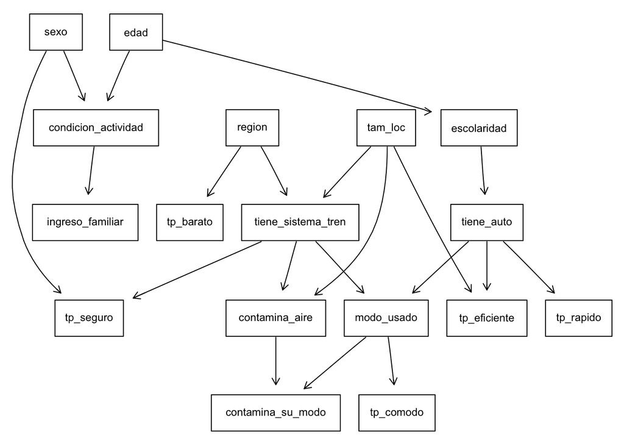

```r
## La lista blanca impone arcos que el algoritmo no puede eliminar. Los seis salen
# de las preguntas de investigación:
#
#   modo_usado     -> tp_comodo          (consulta 1)
#   modo_usado     -> contamina_su_modo  (consulta 3)
#   tiene_auto     -> modo_usado         (si tiene auto evidentemente es uno de los modos que puede usar. No todos los que tienen auto reportan eso como su principal medio de transporte)
#   tam_loc        -> tp_eficiente       (consulta 4
#   sexo           -> tp_seguro          (consulta 2)
#   contamina_aire -> contamina_su_modo  (Al evaluarse por primera vez el dag, el arco era al revés pero hace más sentido de esta forma)

wl_a = data.frame(
  from = c("modo_usado", "modo_usado", "tiene_auto", "tam_loc", "sexo", "contamina_aire"),
  to   = c("tp_comodo", "contamina_su_modo", "modo_usado", "tp_eficiente",
           "tp_seguro", "contamina_su_modo"),
  stringsAsFactors = FALSE
)

# Algortimo hill climbing que halla el mejor DAG con nuetras restricciones
dag_a = hc(data, blacklist = bl_a, whitelist = wl_a)
graphviz.plot(dag_a)
```

# MODELO B

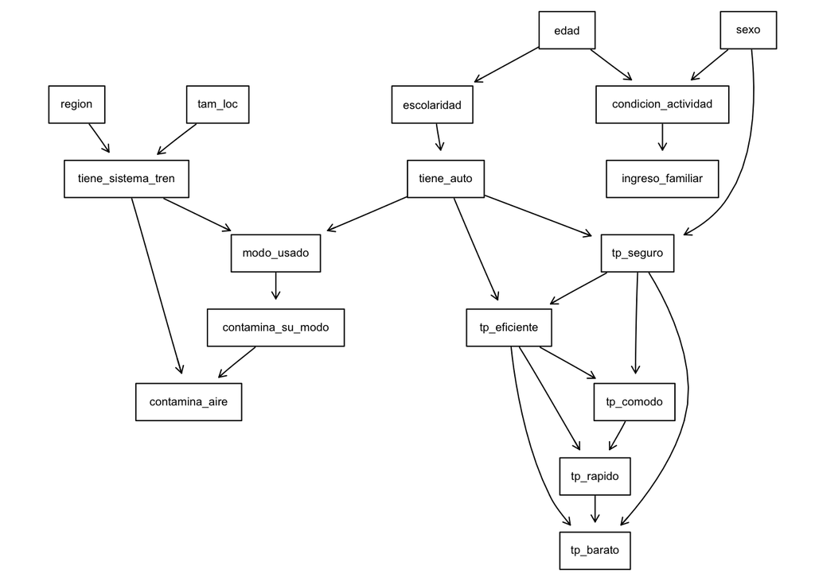

```r
# Supuesto: todo el efecto del nivel socioeconómico sobre la movilidad y
# sobre la evaluación del servicio transita por la disponibilidad de automóvil

# Distinguimos clásica entre personas usuarias que usan el transporte público
# por falta de alternativas y aquellos que sí lo eligen.
nse   = c("escolaridad", "condicion_actividad", "ingreso_familiar")
aguas = c("modo_usado", "tp_eficiente", "tp_rapido", "tp_barato",
           "tp_seguro", "tp_comodo")
bl_cuello = expand.grid(from = nse, to = aguas, stringsAsFactors = FALSE)

# OJO: bl_bat NO se incluye. A diferencia del Modelo A, esta especificación sí
# permite arcos entre los reactivos de evaluación. Ésa es la única restricción
# que relaja respecto de A; en todo lo demás es MÁS restrictivo.
bl_b = rbind(bl_capas, bl_t1, bl_cuello)

# La lista blanca conserva los arcos obligatorios del modelo anterior que siguen aplicando y añade
# los de tiene_auto hacia eficiencia y seguridad percibidas, ya que quien tiene vehículo puede
# evaluar peor el transporte público aun sin utilizarlo.

wl_b = data.frame(
  from = c("tiene_auto", "tiene_auto", "tiene_auto", "sexo", "modo_usado"),
  to   = c("modo_usado", "tp_eficiente", "tp_seguro", "tp_seguro", "contamina_su_modo"),
  stringsAsFactors = FALSE
)

dag_b = hc(data, blacklist = bl_b, whitelist = wl_b)
graphviz.plot(dag_b)
```

# MODELO SIN RESTRICCIONES (HC PURO)

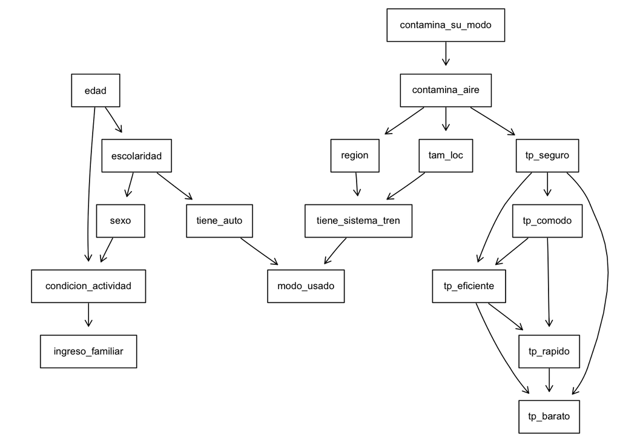

```r
dag_c = hc(data)
graphviz.plot(dag_c)
```

# COMPARACIÓN BIC/AIC A vs B vs Sin restricciones

```r
comparacion = data.frame(
  Modelo = c("A. Jerarquía por capas", "B. Cautividad", "C. Sin restricciones"),
  BIC = c(score(dag_a, data, type = "bic"),
          score(dag_b, data, type = "bic"),
          score(dag_c, data, type = "bic")),
  AIC = c(score(dag_a, data, type = "aic"),
          score(dag_b, data, type = "aic"),
          score(dag_c, data, type = "aic"))
)
comparacion
```

| Modelo | BIC | AIC |
| --- | --- | --- |
| A. Jerarquía por capas | -18492.40 | -18018.16 |
| B. Cautividad | -17827.67 | -17438.74 |
| C. Sin restricciones | -17768.44 | -17382.02 |

```r
# ¿Cuáles son las distancias entre modelos?
mejor_menos_peor = comparacion$BIC[3] - comparacion$BIC[1]
segundo_mejor_menos_peor = comparacion$BIC[2] - comparacion$BIC[1]
mejor_menos_segundo_mejor <- mejor_menos_peor - segundo_mejor_menos_peor

# Reparto de la distancia en BIC
print(round(c(
  total  = mejor_menos_peor,
  A_a_B  = segundo_mejor_menos_peor,  # la distancia que "cuesta" el supuesto de percepciones de servicio condicionalmente independientes
  B_a_C  = mejor_menos_segundo_mejor # el resto de la distancia
), 1))
```

```
total A_a_B B_a_C
724.0 664.7  59.2
```

```r
# Porcentajes de la distancia del mejor al peor
print(round(100 * c(
  A_a_B = segundo_mejor_menos_peor,
  B_a_C = mejor_menos_segundo_mejor
) / mejor_menos_peor, 0))
```

```
A_a_B B_a_C
   92     8
```

# JUSTIFICACIÓN DE MODELO A

Conservamos el Modelo A como modelo de consulta pese a tener el peor ajuste. Las restricciones del Modelo A se especificaron a priori, derivadas de las preguntas de investigación. El supuesto de independencia condicional de la batería afecta únicamente a las consultas que involucran probabilidades conjuntas variables de evaluación. Las tres primeras consultas no lo tocan. Como la cuarta sí, se reporta desde la frecuencia condicional observada, para comparar la discrepancia.